# Elegans: DE analysis

Lieven Clement

statOmics, Ghent University (https://statomics.github.io)

After fertilization but prior to the onset of zygotic transcription, the C. elegans zygote cleaves asymmetrically to create the anterior AB and posterior P1 blastomeres, each of which goes on to generate distinct cell lineages. To understand how patterns of RNA inheritance and abundance arise after this first asymmetric cell division, we pooled hand-dissected AB and P1 blastomeres and performed RNA-seq. http://www.ncbi.nlm.nih.gov/geo/query/acc.cgi?acc=GSE59943

The reads have been aligned to the genome and summarized to gene level in the Rsubread tutorial.

```r
library(tidyverse)
library(edgeR)
```

#Read featurecounts object

We import the featurecounts object that we have stored.

```r
fc <- readRDS("fcElegans.rds")
names(fc)
```

```
## [1] "counts"     "annotation" "targets"    "stat"
```

```r
counts_featurecounts <- fc$counts
head(counts_featurecounts)
```

```
##                SRR1532959.bam SRR1532960.bam SRR1532961.bam SRR1532962.bam
## WBGene00197333              0              0              0              0
## WBGene00198386              0              0              0              0
## WBGene00015153              0              0              0              0
## WBGene00002061            152            253            157             95
## WBGene00255704              0              0              0              0
## WBGene00235314              0              0              0              0
##                SRR1532963.bam SRR1532964.bam
## WBGene00197333              0              0
## WBGene00198386              0              0
## WBGene00015153              1              2
## WBGene00002061            144            152
## WBGene00255704              0              0
## WBGene00235314              0              0
```

```r
dim(counts_featurecounts)
```

```
## [1] 46904     6
```

```r
fc$stat
```

```
##                           Status SRR1532959.bam SRR1532960.bam SRR1532961.bam
## 1                       Assigned        1657500        1323934        2013110
## 2            Unassigned_Unmapped          98398         257946          67401
## 3           Unassigned_Read_Type              0              0              0
## 4           Unassigned_Singleton              0              0              0
## 5      Unassigned_MappingQuality              0              0              0
## 6             Unassigned_Chimera              0              0              0
## 7      Unassigned_FragmentLength              0              0              0
## 8           Unassigned_Duplicate              0              0              0
## 9        Unassigned_MultiMapping              0              0              0
## 10          Unassigned_Secondary              0              0              0
## 11           Unassigned_NonSplit              0              0              0
## 12         Unassigned_NoFeatures           9430          11104          10279
## 13 Unassigned_Overlapping_Length              0              0              0
## 14          Unassigned_Ambiguity          18542          17985          26523
##    SRR1532962.bam SRR1532963.bam SRR1532964.bam
## 1         1304759        2568046        2208253
## 2           82920         108861          92578
## 3               0              0              0
## 4               0              0              0
## 5               0              0              0
## 6               0              0              0
## 7               0              0              0
## 8               0              0              0
## 9               0              0              0
## 10              0              0              0
## 11              0              0              0
## 12           5867          11931           9791
## 13              0              0              0
## 14          16467          47238          27401
```

## 0.1 Read Meta Data

```r
target <- readRDS("elegansMetaData.rds")
```

# 1 Data Analysis

## 1.1 Setup count object edgeR

```r
dge <- DGEList(fc$counts)
substr(colnames(dge),1,10)==target$Run
```

```
## [1] TRUE TRUE TRUE TRUE TRUE TRUE
```

Order of information in target file and count table is the same

```r
colnames(dge) <- paste0(target$`cell type:ch1`,target$`replicate:ch1`)
cellType <- as.factor(target$`cell type:ch1`)
```

## 1.2 Normalisation

```r
dge <- calcNormFactors(dge)
```

## 1.3 Data exploration

One way to reduce dimensionality is the use of multidimensional scaling (MDS). For MDS, we first have to calculate all pairwise distances between our objects (samples in this case), and then create a (typically) two-dimensional representation where these pre-calculated distances are represented as accurately as possible. This means that depending on how the pairwise sample distances are defined, the two-dimensional plot can be very different, and it is important to choose a distance that is suitable for the type of data at hand.

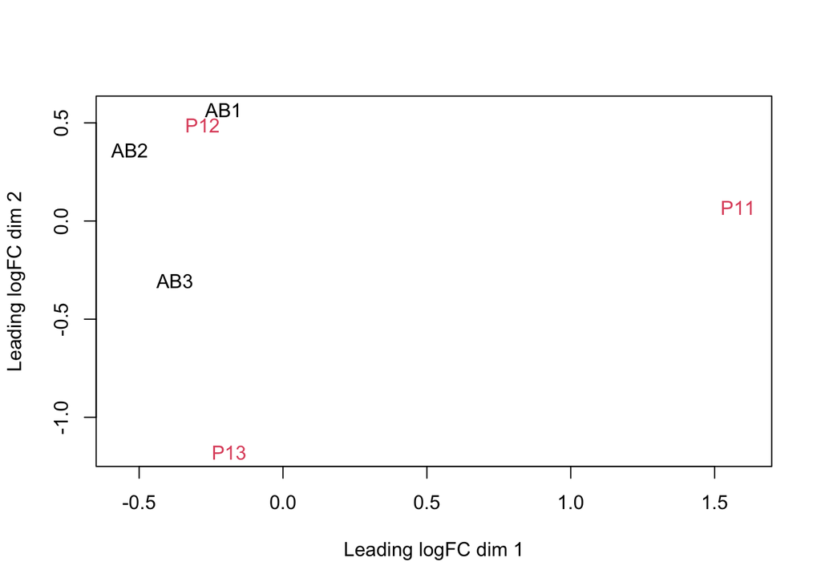

```r
plotMDS(dge, top = 500, col = as.double(cellType))
```

## 1.4 Differential analysis

### 1.4.1 Filtering

```r
design <- model.matrix(~cellType)
keep <- filterByExpr(dge, design)
dge <- dge[keep, ,keep.lib.sizes = FALSE]
```

The option keep.lib.sizes=FALSE causes the library sizes to be recomputed after the filtering. This is generally recommended, although the effect on the downstream analysis is usually small.

The normalisation factors have to be recalculated upon filtering.

```r
dge <- calcNormFactors(dge)
```

### 1.4.2 Fit Model

We first estimate the overdispersion.

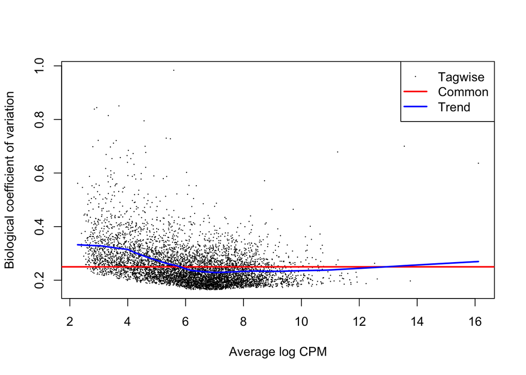

```r
dge <- estimateDisp(dge, design)
plotBCV(dge)
```

Finally, we fit the generalized linear model and perform the test. In the glmLRT function, we indicate which coefficient (which column in the design matrix) that we would like to test for. It is possible to test more general contrasts as well, and the user guide contains many examples on how to do this. The topTags function extracts the top-ranked genes. You can indicate the adjusted p-value cutoff, and/or the number of genes to keep.

```r
fit <- glmFit(dge, design)
lrt <- glmLRT(fit, coef = ncol(design))
ttAll <-topTags(lrt, n = nrow(dge)) # all genes
```

Note, that the workflow with glmFit and glmLRT is no longer the default workflow of edgeR. We will discuss this when we focus on the technical aspects of differential analysis of RNASeq data.

#### 1.4.2.1 Evaluate distribution of p-values

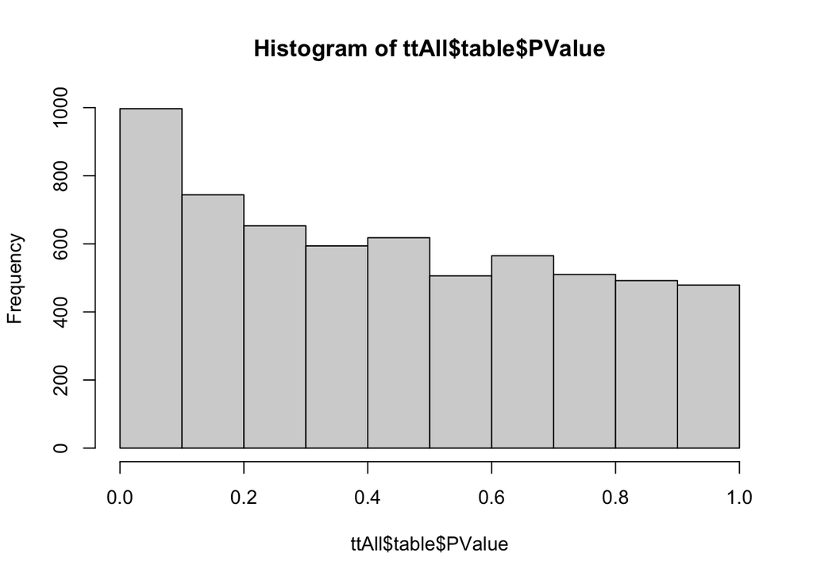

```r
hist(ttAll$table$PValue)
```

#### 1.4.2.2 DE genes?

```r
tt <- topTags(lrt, n = nrow(dge), p.value = 0.05) # genes with adj.p<0.05
knitr::kable(tt)
```

|  | logFC | logCPM | LR | PValue | FDR |
| --- | --- | --- | --- | --- | --- |
| WBGene00011409 | 2.3051280 | 7.119802 | 73.05792 | 0.0000000 | 0.0000000 |
| WBGene00017985 | -1.7957089 | 7.372791 | 62.01882 | 0.0000000 | 0.0000000 |
| WBGene00016824 | -1.8923338 | 6.753206 | 60.58811 | 0.0000000 | 0.0000000 |
| WBGene00019811 | 1.8317181 | 6.588456 | 48.07969 | 0.0000000 | 0.0000000 |
| WBGene00000388 | -1.5819410 | 7.523366 | 45.20634 | 0.0000000 | 0.0000000 |
| WBGene00020948 | -1.4293678 | 9.866419 | 44.42801 | 0.0000000 | 0.0000000 |
| WBGene00000496 | 2.5765059 | 6.137689 | 44.36365 | 0.0000000 | 0.0000000 |
| WBGene00021200 | 2.8405675 | 5.752301 | 43.29921 | 0.0000000 | 0.0000000 |
| WBGene00017397 | 1.8053895 | 4.954892 | 39.44648 | 0.0000000 | 0.0000002 |
| WBGene00010354 | 3.5189772 | 3.594563 | 36.90842 | 0.0000000 | 0.0000008 |
| WBGene00021009 | -2.5009414 | 5.901792 | 35.03340 | 0.0000000 | 0.0000018 |
| WBGene00008823 | -1.4590401 | 6.893432 | 33.67495 | 0.0000000 | 0.0000033 |
| WBGene00009035 | 2.4812880 | 3.637571 | 33.33107 | 0.0000000 | 0.0000037 |
| WBGene00008080 | -1.5849757 | 6.273693 | 31.88531 | 0.0000000 | 0.0000072 |
| WBGene00000863 | -1.3206086 | 6.869690 | 31.18917 | 0.0000000 | 0.0000096 |
| WBGene00009264 | 1.3101438 | 7.737531 | 29.98508 | 0.0000000 | 0.0000168 |
| WBGene00019001 | 1.5310735 | 5.796877 | 29.80333 | 0.0000000 | 0.0000173 |
| WBGene00009793 | -1.5448441 | 6.443390 | 28.72037 | 0.0000001 | 0.0000286 |
| WBGene00016823 | -1.6283682 | 6.822229 | 28.52248 | 0.0000001 | 0.0000300 |
| WBGene00009606 | -1.6836921 | 7.018377 | 27.59933 | 0.0000001 | 0.0000422 |
| WBGene00006562 | 1.2334479 | 8.237130 | 27.59138 | 0.0000001 | 0.0000422 |
| WBGene00004374 | 1.3126857 | 8.205130 | 27.57883 | 0.0000002 | 0.0000422 |
| WBGene00018009 | -1.1679161 | 7.288469 | 27.24427 | 0.0000002 | 0.0000480 |
| WBGene00009921 | -1.4520825 | 7.509272 | 27.08123 | 0.0000002 | 0.0000501 |
| WBGene00005022 | 3.0989396 | 3.072409 | 26.65312 | 0.0000002 | 0.0000600 |
| WBGene00012031 | 1.6710488 | 5.983430 | 26.46157 | 0.0000003 | 0.0000637 |
| WBGene00007145 | 1.3911358 | 5.955030 | 26.23073 | 0.0000003 | 0.0000691 |
| WBGene00000550 | 1.8567741 | 6.986777 | 25.65848 | 0.0000004 | 0.0000869 |
| WBGene00008464 | -1.3691265 | 6.098891 | 25.59697 | 0.0000004 | 0.0000869 |
| WBGene00002276 | -1.7151651 | 7.783958 | 25.58421 | 0.0000004 | 0.0000869 |

[output cut: 81 more lines]

| x |
| --- |
| BH |

| x |
| --- |
| cellTypeP1 |

| x |
| --- |
| glm |

There are 111 genes differentially expressed.

### 1.4.3 Plots

We first make a volcanoplot and an MA plot.

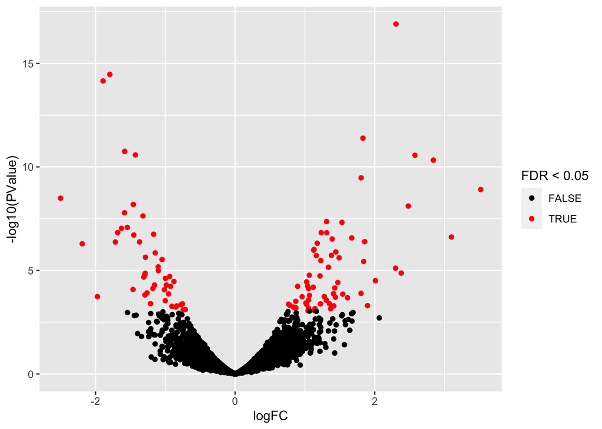

```r
library(ggplot2)
volcano<- ggplot(ttAll$table,aes(x=logFC,y=-log10(PValue),color=FDR<0.05)) + geom_point() + scale_color_manual(values=c("black","red"))
volcano
```

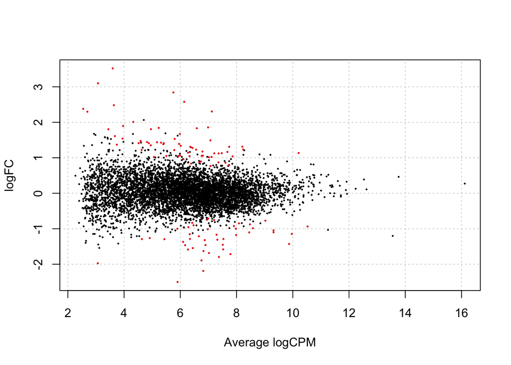

```r
plotSmear(lrt, de.tags = row.names(tt$table))
```

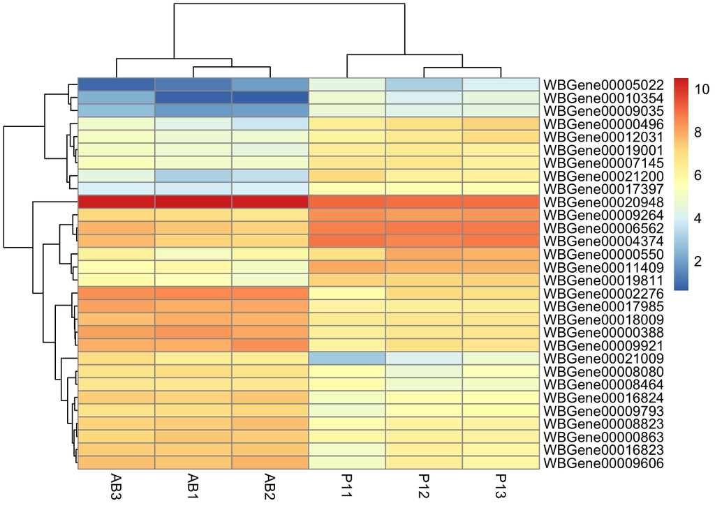

```r
library(pheatmap)
pheatmap(cpm(dge, log = TRUE)[rownames(tt$table)[1:30],])
```